# Análise de Gastos dos Deputados

Diogo Florêncio

26 de outubro de 2017

A CEAP (cota para o exercício da atividade parlamentar) é uma cota única mensal destinada a custear os gastos dos deputados exclusivamente vinculados ao exercício da atividade parlamentar. Exemplos de despesa desse tipo são: passagens aéreas, telefonia, serviços postais, manutenção de escritórios de apoio à atividade parlamentar, assinatura de publicações, fornecimento de alimentação ao parlamentar, hospedagem, outras despesas com locomoção, contemplando locação ou fretamento de aeronaves, veículos automotores e embarcações, serviços de táxi, pedágio e estacionamento e passagens terrestres. Os dados desta análise estão disponíveis aqui.

### Quais os partidos que mais fazem uso da CEAP? Quais os partidos que menos fazem uso?

Para responder essas perguntas considerei a quantidade de documentos fiscais por partido, sem considerar o valor das despesas. Documentos referentes a estornos não foram considerados.

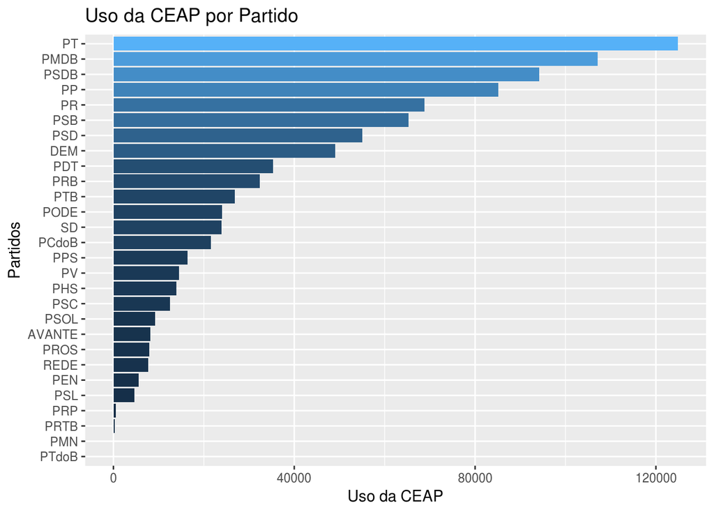

```r
uso_ceap <- amostra %>% filter(valorLíquido > 0) %>%
  group_by(sgPartido) %>%
  summarise(qtd_CEAP = n())

uso_ceap %>%
  ggplot(aes(x = reorder(sgPartido, qtd_CEAP), y = qtd_CEAP, fill = qtd_CEAP)) +
  geom_bar(stat="identity") +
  theme(legend.position="none") +
  coord_flip() +
  xlab("Partidos") + ylab("Uso da CEAP") +
  ggtitle("Uso da CEAP por Partido")
```

O gráfico evidência os partidos que usam a CEAP com maior frequência, estes são: PT, PMDB, PSDB e PP. Também é fácil identificar os partidos com menor frequência: PTdoB, PMN, PRTB e PRP.

### Quais partidos mais gastam por meio da CEAP? Quais gastam menos?

Neste caso, foi considerado a soma do valor dos documentos fiscais por partido, excluindo desse total valores referentes a estornos.

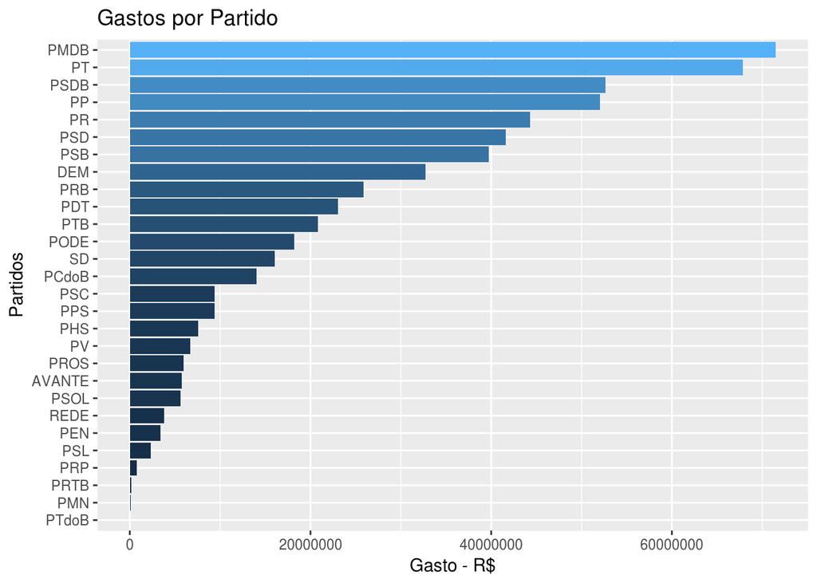

```r
gasto_ceap <- amostra %>%
  group_by(sgPartido) %>%
  summarise(gasto = sum(valorLíquido))

gasto_ceap %>%
  ggplot(aes(x = reorder(sgPartido, gasto), y = gasto, fill = gasto)) +
  geom_bar(stat="identity") +
  theme(legend.position="none") +
  coord_flip() +
  xlab("Partidos") + ylab("Gasto - R$") +
  ggtitle("Gastos por Partido")
```

Os partidos que mais gastam também são os partidos que mais usam a CEAP. O mesmo resultado é válido para os partidos que menos gastam. Existe apenas uma divergência entre os resultados, apesar do PT ser o partido com maior frequência de uso o PMDB apresenta maiores gastos em sua atividade parlamentar.

### Quais as despesas mais frequentes na CEAP?

Para esta questão, foram análisadas os tipos de despesas mais comuns registrados nos documentos fiscais.

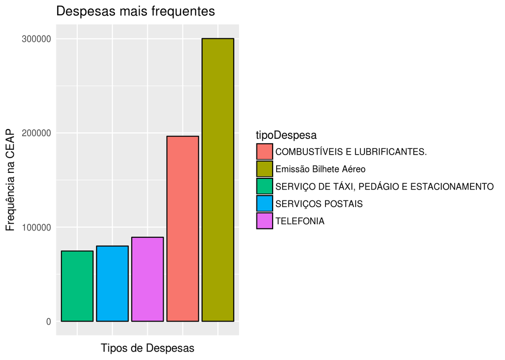

```r
despesas_comuns <- amostra %>%
  group_by(tipoDespesa) %>%
  summarise(qtd = n())

despesas_comuns %>%
  top_n(despesas_comuns$qtd, n = 5) %>%
  ggplot(aes(x = reorder(tipoDespesa, qtd), y = qtd, fill = tipoDespesa)) +
  geom_bar(colour="black", stat="identity") +
  theme(axis.text.x=element_blank(), axis.ticks=element_blank()) +
  ylab("Frequência na CEAP") + xlab("Tipos de Despesas") +
  ggtitle("Despesas mais frequentes")
```

As 5 despesas mais comuns na CEAP são exibidas no gráfico. É possível perceber que despesas com *Emissão de Bilhete Aéreo* e *Combistíveis e Lubrificantes* são bem mais frequentes do que as de mais.

### Quais as despesas mais caras?

Para avaliar as despesas mais caras, foi feito um somatório do valor dos documentos fiscais por despesas. Documentos referentes a estornos foram debitados do valor total de sua respectiva despesa.

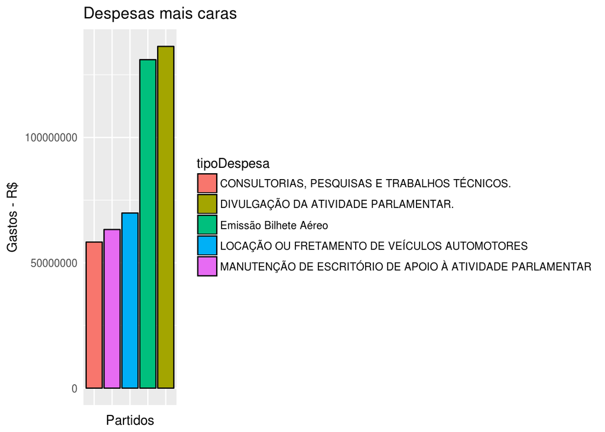

```r
despesas_mais_caras = amostra %>%
  group_by(tipoDespesa) %>%
  summarise(valor = sum(valorLíquido))

despesas_mais_caras%>%
  top_n(despesas_mais_caras$valor, n = 5) %>%
  ggplot(aes(x = reorder(tipoDespesa, valor), y = valor, fill = tipoDespesa)) +
  geom_bar(colour="black", stat="identity") +
  theme(axis.text.x=element_blank(), axis.ticks=element_blank()) +
  ylab("Gastos - R$") + xlab("Partidos") +
  ggtitle("Despesas mais caras")
```

É exibido as 5 despesas mais caras da CEAP. Das despesas mais caras apenas *Emissão de Bilhete Aéreo* está dentre as mais frequentes. Também é notável que *Divulgação da Atividade Parlamentar* e *Emissão de Bilhete Aéreo* são custam bem mais que as de mais.

### Levando em conta o estado pelo qual o deputado se elegeu, quais os estados que mais fazem uso da CEAP? Quais os que menos fazem uso? Quais gastam mais? Quais gastam menos?

Para responder essas questões foram análisados a quantidade e o valor total dos documentos fiscais por estado. Novamente, documentos referentes a estornos foram debitados do valor total do respectivo estados.

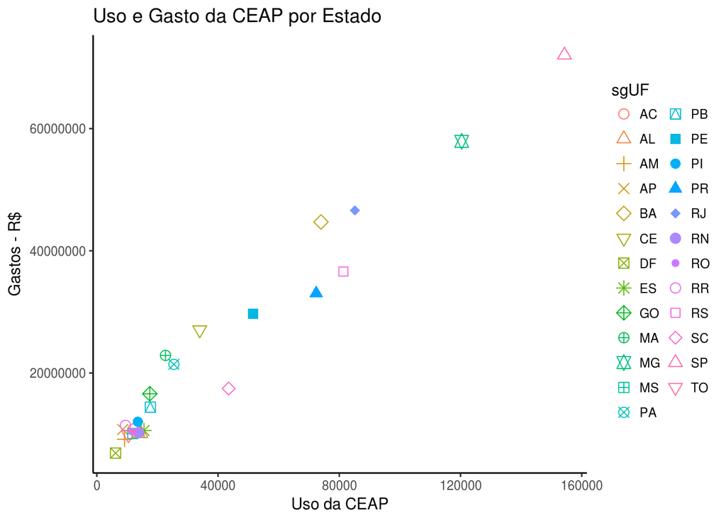

```r
uso_ceap_estados = amostra %>%
  filter(sgUF != "SE") %>%
  filter(sgUF != "MT") %>%
  group_by(sgUF) %>%
  summarise(qtd = n(),
            valor = sum(valorLíquido))

uso_ceap_estados %>%
  ggplot(aes(x = qtd, y = valor, color = sgUF)) +
  geom_point(size = 3, shape = as.factor(uso_ceap_estados$sgUF)) +
  theme_classic() +
  xlab("Uso da CEAP") + ylab("Gastos - R$") +
  ggtitle("Uso e Gasto da CEAP por Estado")
```

O gráfico exibe no eixo das abscissas os valor realtivo a frequência de uso, o eixo das ordenadas representa o valor em reais das despesas por estado. os estados são representados por cores e marcas.Ou seja, quanto mais a baixo estiver um estado menos ele gasta, quanto mais a esquerda ele estiver menos ele usa a CEAP.

É possível percerber a óbvia correlação linear positiva entre as variáveis *Uso* e *Gasto*. O estado que menos usa e gasta é o *DF*; e oque mais usa e consequentemente gasta é *SP*. Claramente isto está relacionado a densidade polulacional dos estados.

### Quais os parlamentares que mais gastam com CEAP e quais os que menos gastam?

Esta questão foi respondida por meio do somatório do valor dos documentos fiscais de cada parlamentar. Obviamente, documentos referentes a estornos foram debitados do valor total do parlamentar.

```r
gastos_parlamentar <- amostra %>% group_by(nomeParlamentar) %>% summarise(UF = first(sgUF), gastos = sum(valorLíquido))

top3_gastos_parlamentar <- bind_rows(top_n(gastos_parlamentar, n = 3), top_n(gastos_parlamentar, n = -3))
```

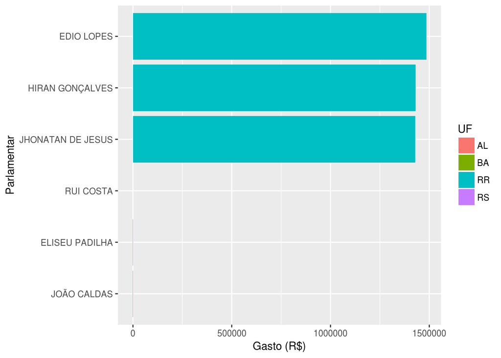

```r
ggplot(top3_gastos_parlamentar, aes(x = reorder(nomeParlamentar, gastos), y = gastos, fill = UF)) +
  geom_bar(stat = "identity") +
  coord_flip() +
  labs(x = "Parlamentar", y = "Gasto (R$)")
```

### Existe correlação entre a quantidade de gastos no exterior e o valor restituído da CEAP?

Nenhuma despesa no exterior foi restituída.

### Quais os estados cujos deputados gastam mais no exterior? Quais os estados cujos deputados gastam menos no exterior?

Afim de responder esta questão foi relacionado o total dos gastos no exterior para cada estado.

```r
estados_exterior <- amostra %>%
  filter(tipoDocumento == 2) %>%
  group_by(sgUF) %>%
  summarise(gasto = sum(valorLíquido))

estados_exterior <- bind_rows(top_n(estados_exterior, n = 10), top_n(estados_exterior, n = -10))
```

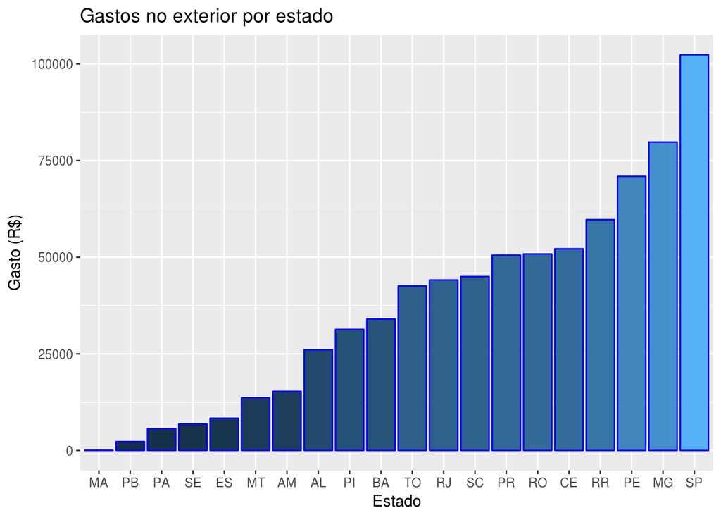

```r
ggplot(estados_exterior, aes(x = reorder(sgUF, gasto), y = gasto, fill = gasto)) +
  geom_bar(stat = "identity",color="blue") +
  theme(legend.position="none") +
  labs(x = "Estado", y = "Gasto (R$)") +
  ggtitle("Gastos no exterior por estado")
```

Os 10 estados que mais e menos gastam no exteriorsão exibidos no gráfico. O estado com maior gasto é São Paulo e com menor gasto é o Maranhão.

### Quais os deputados que mais ultrapassam o limite de CEAP do seu estado?

Para esta pergunta, foi feita uma análise por meio do valor total de gastos por deputado e então subtraído o limite do seu respectivo estado.

[figure not shown]

```r
parlamentares_limite_mensal <- merge(gastos_parlamentar,limite_mensal) %>%
  mutate(w = gastos - limite_mensal)

parlamentares_limite_mensal %>%
  top_n(parlamentares_limite_mensal$w, n = 5) %>%
  ggplot(aes(x = nomeParlamentar, y = w, fill = UF)) +
  geom_bar(colour="black", stat="identity") +
  coord_flip()+
  ylab("Frequência na CEAP") + xlab("Tipos de Despesas") +
  ggtitle("Despesas mais frequentes")
```

O gráfico exibe os 5 parlamentares que mais ultrapassam o limite dos seus estados. Pode-se perceber que os deputados que mais gastam também são os que mais ultrapassam seu o limite do seu estado.